# hecr 2D Recipes

## One plan multiple coordinates

To query multiple coordinates out of the hdf file, simply provide a matrix, or an even length vector of coordinates. The matrix must be *mx2* here *m* is the number of coordinates and 2 is the *x* and *y* coordinates (in that order). There is no limit on *m*. The other option is a vector of pairs of coordinates, therefore of even length. We currently support vector for quick queries and testing but a sophisicated script should be supplying a matrix as input.

```r
# define a vector of coordinates
coords_vs <- c(6570468.12123,   1881034.38489,
            6570186.03222,  1880216.19001,
            6570167.9381,   1879820.21836,
            6570141.81282,  1879703.42988,
            6570114.02745,  1879601.38152,
            6570108.19281,  1879582.69751,
            6569969.28791,  1879291.13936
)

# you can also supply a matrix
coords_m <- matrix(coords_vs, ncol=2, byrow = TRUE)

data <- hec_two(h, coords_m)

dplyr::glimpse(data)

# Observations: 679
# Variables: 8
# $ datetime         <dttm> 2018-02-07 00:00:00, 2018-02-07 00:15:00, 2018-02-07 00:30:00, ...
# $ plan_id          <chr> "Existing_LidarCalib_20180830", "Existing_LidarCalib_20180830", ...
# $ plan_file        <chr> "LowerDeerCreek_2018.p10", "LowerDeerCreek_2018.p10", "LowerDeer...
# $ time_series_type <chr> "Water Surface", "Water Surface", "Water Surface", "Water Surfac...
# $ hdf_cell_index   <dbl> 391410, 391410, 391410, 391410, 391410, 391410, 391410, 391410, ...
# $ xin              <dbl> 6570468.12123, 6570468.12123, 6570468.12123, 6570468.12123, 6570...
# $ yin              <dbl> 1881034.38489, 1881034.38489, 1881034.38489, 1881034.38489, 1881...
# $ values           <dbl> 403.998809814453, 403.998809814453, 403.998809814453, 403.998809...
```

When you query multiple coordinates, the “hdf_cell_index” becomes an importnat attribute, it maps the input coordinate (that you supplied) to the corresponding cell in the model that hecr determined to be the closest. You can use this attrbute to, group by, color and other “group” operations.

Here we plot the time series based on these inputs, and color by the cell index. Note that the cell index a numeric and thus needs to casted to factor or character for ggplot to properly display these are different time series.

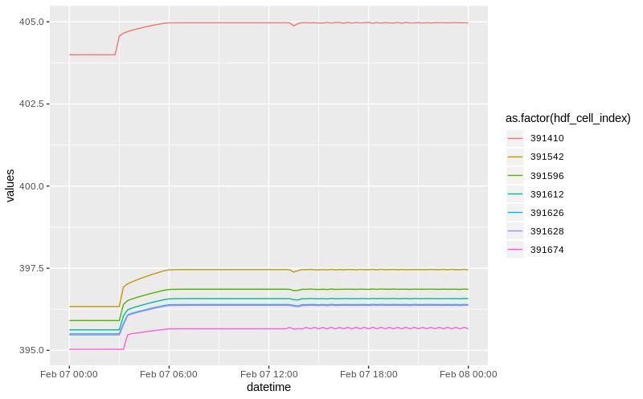

multiple coords

```r
data %>% ggplot(aes(datetime, values, color=as.factor(hdf_cell_index))) +
  geom_line()
```

## One Plan, mutiple coodinates for one timestamp (Profile Line)

With the optional time stamp parameter, you can fix the time portion of query to a desired stamp and query values for a large number of coordinates. Although you could query all data then perform a filter to a time stamp (which you can totally do), passing in the time stamp allows you to save a lot memory resources since the package will only read in the time stamp desired straight from the hdf file (using hdf5r).

```r
coords_m

tstamp <- "2018-02-07 01:15:00"

data <- hec_two(f, coords_m, time_stamp = tstamp)

glimpse(data)

# Observations: 7
# Variables: 8
# $ datetime         <dttm> 2018-02-07 01:15:00, 2018-02-07 01:15:00, 2018-02-07 01:15:00, ...
# $ plan_id          <chr> "Existing_LidarCalib_20180830", "Existing_LidarCalib_20180830", ...
# $ plan_file        <chr> "LowerDeerCreek_2018.p10", "LowerDeerCreek_2018.p10", "LowerDeer...
# $ time_series_type <chr> "Water Surface", "Water Surface", "Water Surface", "Water Surfac...
# $ hdf_cell_index   <dbl> 391410, 391542, 391596, 391612, 391626, 391628, 391674
# $ xin              <dbl> 6570468.12123, 6570186.03222, 6570167.93810, 6570141.81282, 6570...
# $ yin              <dbl> 1881034.38489, 1880216.19001, 1879820.21836, 1879703.42988, 1879...
# $ values           <dbl> 403.998809814453, 396.334991455078, 395.906250000000, 395.625000...
```

As expected the output now only has 7 observations, one for each coordinate, each reporting the value observed at the time specified.

Here we plot this:

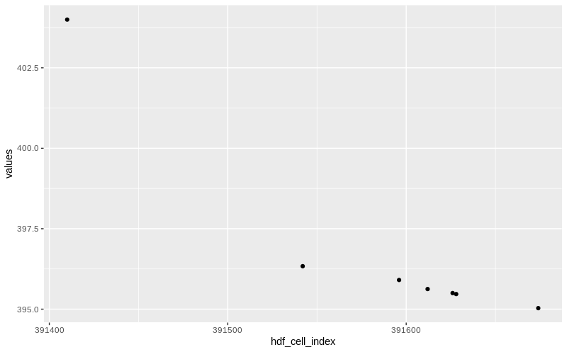

profile line

```r
data %>%
  ggplot(aes(hdf_cell_index, values)) + geom_point()
```